# Assignment 4

DATA 311 - Machine Learning

Author

Maxim Storozhuk (40965642)

# Exercise 1

Clustering and classification have some key differences.

Classification is **supervised**, where data points are assigned to pre-determined groups. The model learns patterns in the data to predict the class labels of new, unseen data.

Clustering is **unsupervised**, where data points are divided into groups. However, algorithm does not get any information about the group structure of the data. It can not classify anything correctly or incorrectly, but it looks for similarities in the data to determine which other data points a singular data point is most similar to.

Classification Example: Determining if an email is spam or not spam. There are two distinct categories (spam or not spam) for the classification algorithm to choose from.

Clustering Example: Identifying regions with similar climates. These regions do not have labels, but they have various types of data that could be used to find similarities between regions’ climates.

# Exercise 2

```r
library(dplyr)
library(caret)
library(palmerpenguins)
data(package ='palmerpenguins')
data <- penguins
head(data)
```

| species | island | bill_length_mm | bill_depth_mm | flipper_length_mm | body_mass_g | sex | year |
| --- | --- | --- | --- | --- | --- | --- | --- |
| Adelie | Torgersen | 39.1 | 18.7 | 181 | 3750 | male | 2007 |
| Adelie | Torgersen | 39.5 | 17.4 | 186 | 3800 | female | 2007 |
| Adelie | Torgersen | 40.3 | 18.0 | 195 | 3250 | female | 2007 |
| Adelie | Torgersen | NA | NA | NA | NA | NA | 2007 |
| Adelie | Torgersen | 36.7 | 19.3 | 193 | 3450 | female | 2007 |
| Adelie | Torgersen | 39.3 | 20.6 | 190 | 3650 | male | 2007 |

```r
str(data)
```

```
tibble [344 × 8] (S3: tbl_df/tbl/data.frame)
 $ species          : Factor w/ 3 levels "Adelie","Chinstrap",..: 1 1 1 1 1 1 1 1 1 1 ...
 $ island           : Factor w/ 3 levels "Biscoe","Dream",..: 3 3 3 3 3 3 3 3 3 3 ...
 $ bill_length_mm   : num [1:344] 39.1 39.5 40.3 NA 36.7 39.3 38.9 39.2 34.1 42 ...
 $ bill_depth_mm    : num [1:344] 18.7 17.4 18 NA 19.3 20.6 17.8 19.6 18.1 20.2 ...
 $ flipper_length_mm: int [1:344] 181 186 195 NA 193 190 181 195 193 190 ...
 $ body_mass_g      : int [1:344] 3750 3800 3250 NA 3450 3650 3625 4675 3475 4250 ...
 $ sex              : Factor w/ 2 levels "female","male": 2 1 1 NA 1 2 1 2 NA NA ...
 $ year             : int [1:344] 2007 2007 2007 2007 2007 2007 2007 2007 2007 2007 ...
```

```r
summary(data)
```

```
      species          island    bill_length_mm  bill_depth_mm
 Adelie   :152   Biscoe   :168   Min.   :32.10   Min.   :13.10
 Chinstrap: 68   Dream    :124   1st Qu.:39.23   1st Qu.:15.60
 Gentoo   :124   Torgersen: 52   Median :44.45   Median :17.30
                                 Mean   :43.92   Mean   :17.15
                                 3rd Qu.:48.50   3rd Qu.:18.70
                                 Max.   :59.60   Max.   :21.50
                                 NA's   :2       NA's   :2
 flipper_length_mm  body_mass_g       sex           year
 Min.   :172.0     Min.   :2700   female:165   Min.   :2007
 1st Qu.:190.0     1st Qu.:3550   male  :168   1st Qu.:2007
 Median :197.0     Median :4050   NA's  : 11   Median :2008
 Mean   :200.9     Mean   :4202                Mean   :2008
 3rd Qu.:213.0     3rd Qu.:4750                3rd Qu.:2009
 Max.   :231.0     Max.   :6300                Max.   :2009
 NA's   :2         NA's   :2
```

```r
data <- na.omit(data)
summary(data)
```

```
      species          island    bill_length_mm  bill_depth_mm
 Adelie   :146   Biscoe   :163   Min.   :32.10   Min.   :13.10
 Chinstrap: 68   Dream    :123   1st Qu.:39.50   1st Qu.:15.60
 Gentoo   :119   Torgersen: 47   Median :44.50   Median :17.30
                                 Mean   :43.99   Mean   :17.16
                                 3rd Qu.:48.60   3rd Qu.:18.70
                                 Max.   :59.60   Max.   :21.50
 flipper_length_mm  body_mass_g       sex           year
 Min.   :172       Min.   :2700   female:165   Min.   :2007
 1st Qu.:190       1st Qu.:3550   male  :168   1st Qu.:2007
 Median :197       Median :4050                Median :2008
 Mean   :201       Mean   :4207                Mean   :2008
 3rd Qu.:213       3rd Qu.:4775                3rd Qu.:2009
 Max.   :231       Max.   :6300                Max.   :2009
```

# Exercise 3

```r
selected_data <- data %>% select(bill_length_mm, bill_depth_mm, flipper_length_mm, body_mass_g)
distance_matrix <- dist(scale(selected_data), method="euclidean") #scaling the data is good practice
class(distance_matrix)
```

```
[1] "dist"
```

# Exercise 4

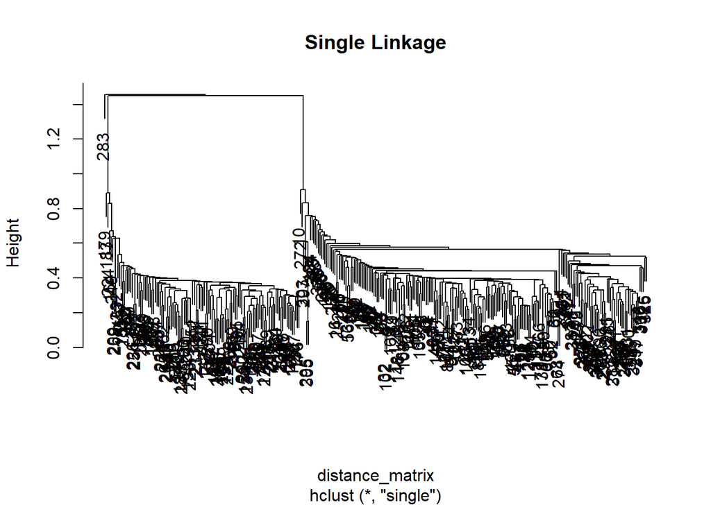

```r
#assuming to leave out centroid linkage
singleLinkage <- hclust(distance_matrix, method = "single")
averageLinkage <- hclust(distance_matrix, method = "average")
completeLinkage <- hclust(distance_matrix, method = "complete")
plot(singleLinkage, main = "Single Linkage")
```

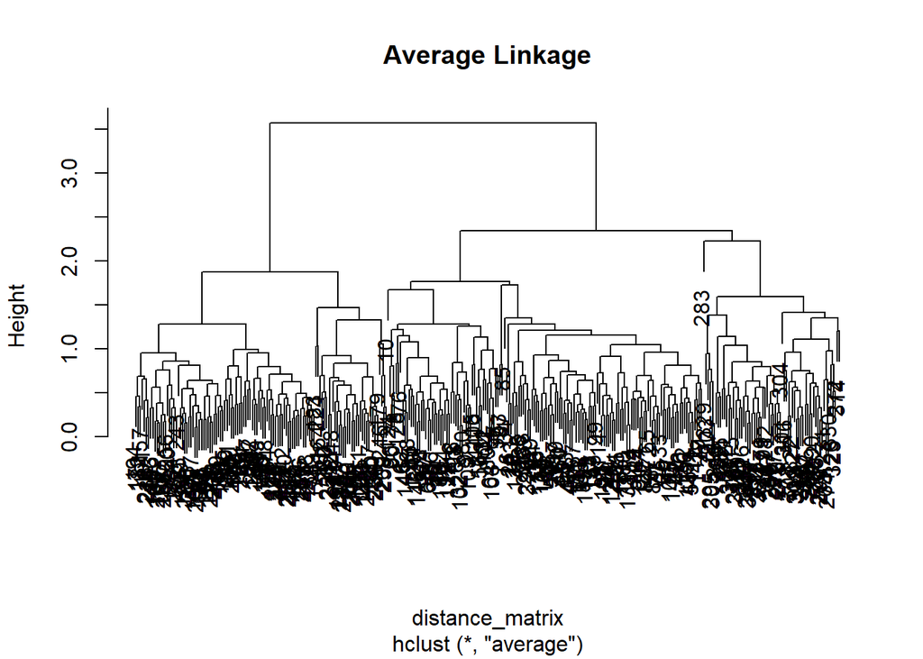

```r
plot(averageLinkage, main = "Average Linkage")
```

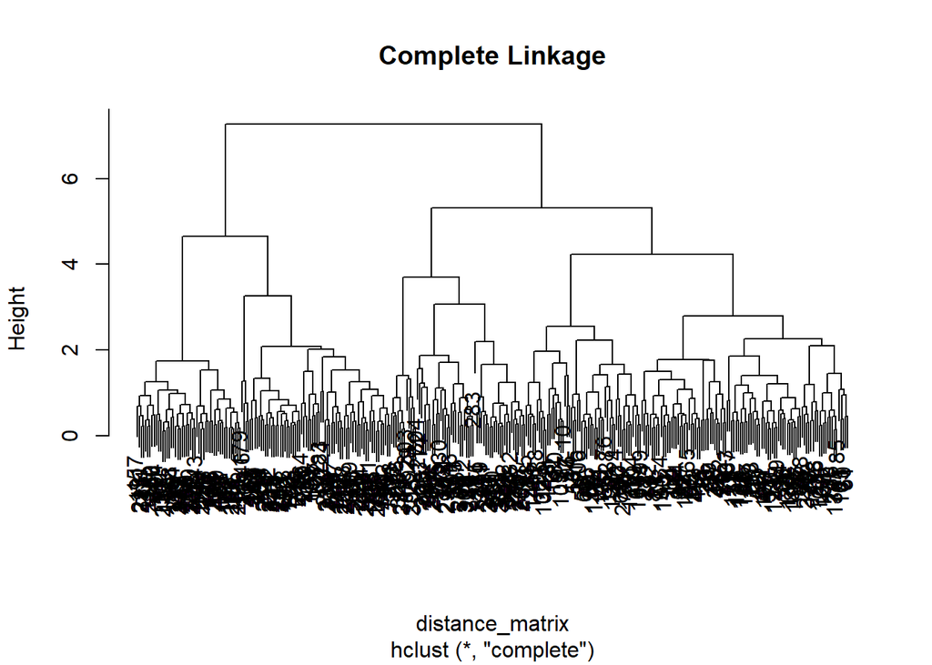

```r
plot(completeLinkage, main = "Complete Linkage")
```

# Exercise 5

Generally, complete linkage is considered the best method. Let’s analyze the dendograms to see if this holds for this dataset.

The single linkage dendogram appears to be a mess, which is as expected. It has clearly fallen victim to chaining. It provides a significantly different solution in comparison to average linkage and complete linkage.

The average linkage dendogram doesn’t look too bad, and it is fairly similar to the complete linkage one. The average linkage dendogram gets cluttered a bit higher up than the complete linkage one. For that reason, as well as complete linkage typically being considered the best method, I believe **complete linkage** is the best method for this problem.

# Exercise 6

Looking ahead at Exercise 7, we need to calculate the misclassification rate for, and compare all of species, island, year, and sex. Species, island, and year all have 3 possible values, which would mean we would need to consider 3 clusters. However, sex only has 2 possible values, which would mean that we would compare 2 possible values. For that reason, we will need to consider both the cases of 2 clusters, and 3 clusters.

```r
cluster3 <- cutree(completeLinkage, 3)
cluster2 <- cutree(completeLinkage, 2)
freqTable3 <- table(cluster3)
print(freqTable3)
```

```
cluster3
  1   2   3
151  63 119
```

```r
freqTable2 <- table(cluster2)
print(freqTable2)
```

```
cluster2
  1   2
214 119
```

# Exercise 7

```r
#display tables for all variables
table(cluster3, data$species)
```

```
cluster3 Adelie Chinstrap Gentoo
       1    145         6      0
       2      1        62      0
       3      0         0    119
```

```r
table(cluster3, data$island)
```

```
cluster3 Biscoe Dream Torgersen
       1     44    61        46
       2      0    62         1
       3    119     0         0
```

```r
table(cluster3, as.factor(data$year))
```

```
cluster3 2007 2008 2009
       1   47   52   52
       2   23   16   24
       3   33   45   41
```

```r
table(cluster2, data$sex)
```

```
cluster2 female male
       1    107  107
       2     58   61
```

```r
#adjust labels for clustering algorithm, to best match classification
speciesLabels <- c("Adelie", "Chinstrap", "Gentoo")
islandLabels <- c("Torgersen", "Dream", "Biscoe")
yearLabels <- c("2008", "2007", "2009") #no real good matchup for this one, but we also already know this isn't what is being clustered
sexLabels <- c("female", "male") #again, no good matchup, but we can tell this isn't what is being clustered

c3Species <- factor(speciesLabels[cluster3], levels = levels(data$species))
c3Island <- factor(islandLabels[cluster3], levels = levels(data$island))
c3Year <- factor(yearLabels[cluster3], levels = levels(as.factor(data$year)))
c2Sex <- factor(sexLabels[cluster2], levels = levels(data$sex))

CMSpecies <- confusionMatrix(c3Species, data$species)
CMIsland <- confusionMatrix(c3Island, data$island)
CMYear <- confusionMatrix(c3Year, as.factor(data$year))
CMSex <- confusionMatrix(c2Sex, data$sex)

accSpecies <- CMSpecies$overall['Accuracy']
accIsland <- CMIsland$overall['Accuracy']
accYear <- CMYear$overall['Accuracy']
accSex <- CMSex$overall['Accuracy']

MCRSpecies <- 1 - as.numeric(accSpecies)
MCRIsland <- 1 - as.numeric(accIsland)
MCRYear <- 1 - as.numeric(accYear)
MCRSex <- 1 - as.numeric(accSex)

MCRSpecies
```

```
[1] 0.02102102
```

```r
MCRIsland
```

```
[1] 0.3183183
```

```r
MCRYear
```

```
[1] 0.6516517
```

```r
MCRSex
```

```
[1] 0.4954955
```

**Species** has the lowest misclassification rate by far, so we can conclude that the clustering algorithm is clustering by species.

# Exercise 8

```r
#the Kmeans function in R only accepts data with numeric arguments, so we will make a separate data frame which only has numeric arguments within in
numeric_data <- data
numeric_data$sex <- as.numeric(data$sex)
numeric_data$species <- as.numeric(data$species)
numeric_data$island <- as.numeric(data$island)
numeric_data$year <- as.numeric(as.factor(data$year))
numeric_data$flipper_length_mm <- as.numeric(data$flipper_length_mm)
numeric_data$body_mass_g <- as.numeric(data$body_mass_g)

set.seed(40965642/2)
kmeans2 <- kmeans(scale(numeric_data), centers = 2)
kmeans2Results <- kmeans2$cluster
kmeans2Results
```

```
  [1] 2 2 2 2 2 2 2 2 2 2 2 2 2 2 2 2 2 2 2 2 2 2 2 2 2 2 2 2 2 2 2 2 2 2 2 2 2
 [38] 2 2 2 2 2 2 2 2 2 2 2 2 2 2 2 2 2 2 2 2 2 2 2 2 2 2 2 2 2 2 2 2 2 2 2 2 2
 [75] 2 2 2 2 2 2 2 2 2 2 2 2 2 2 2 2 2 2 2 2 2 2 2 2 2 2 2 2 2 2 2 2 2 2 2 2 2
[112] 2 2 2 2 2 2 2 2 2 2 2 2 2 2 2 2 2 2 2 2 2 2 2 2 2 2 2 2 2 2 2 2 2 2 2 1 1
[149] 1 1 1 1 1 1 1 1 1 1 1 1 1 1 1 1 1 1 1 1 1 1 1 1 1 1 1 1 1 1 1 1 1 1 1 1 1
[186] 1 1 1 1 1 1 1 1 1 1 1 1 1 1 1 1 1 1 1 1 1 1 1 1 1 1 1 1 1 1 1 1 1 1 1 1 1
[223] 1 1 1 1 1 1 1 1 1 1 1 1 1 1 1 1 1 1 1 1 1 1 1 1 1 1 1 1 1 1 1 1 1 1 1 1 1
[260] 1 1 1 1 1 1 2 2 2 2 2 2 2 2 2 2 2 2 2 2 2 2 2 2 2 2 2 2 2 2 2 2 2 2 2 2 2
[297] 2 2 2 2 2 2 2 2 2 2 2 2 2 2 2 2 2 2 2 2 2 2 2 2 2 2 2 2 2 2 2 2 2 2 2 2 2
```

Observations 1-146 are put in group 2, observations 147-265 are put in group 1, and observations 266-333 are put in group 2.

# Exercise 9

I would expect the K-means algorithm to cluster by **sex**, as it is the only categorical variable with two possible classifications.

```r
factorSex <- as.factor(numeric_data$sex)
factorK2Results <- as.factor(kmeans2Results)
CMSexKMeans <- confusionMatrix(factorK2Results, factorSex)
CMSexKMeans
```

```
Confusion Matrix and Statistics

          Reference
Prediction   1   2
         1  58  61
         2 107 107

               Accuracy : 0.4955
                 95% CI : (0.4405, 0.5505)
    No Information Rate : 0.5045
    P-Value [Acc > NIR] : 0.6493890

                  Kappa : -0.0116

 Mcnemar's Test P-Value : 0.0005169

            Sensitivity : 0.3515
            Specificity : 0.6369
         Pos Pred Value : 0.4874
         Neg Pred Value : 0.5000
             Prevalence : 0.4955
         Detection Rate : 0.1742
   Detection Prevalence : 0.3574
      Balanced Accuracy : 0.4942

       'Positive' Class : 1
```

It is clear that the K-means algorithm with 2 centers did not align with sex. These results look identical to the results found by the complete linkage hierarchical clustering algorithm cut at 2 categories, so a valid assumption would be that the k-means algorithm also tried to group by species.

# Exercise 10

```r
set.seed(40965642/2)
kmeans3 <- kmeans(scale(numeric_data), centers = 3)
kmeans3Results <- kmeans3$cluster

table(kmeans3Results, numeric_data$species)
```

```
kmeans3Results   1   2   3
             1   0   0 119
             2   5  63   0
             3 141   5   0
```

```r
table(kmeans3Results, numeric_data$island)
```

```
kmeans3Results   1   2   3
             1 119   0   0
             2   1  64   3
             3  43  59  44
```

```r
newMapping <- c(3, 2, 1)
kmeans3Mapped <- newMapping[kmeans3Results]

factorSpecies <- as.factor(numeric_data$species)
factorK3Species <- as.factor(kmeans3Mapped)

factorIsland <- as.factor(numeric_data$island)
factorK3Island <- as.factor(kmeans3Results)

CMSpeciesK <- confusionMatrix(factorK3Species, factorSpecies)
CMIslandK <- confusionMatrix(factorK3Island, factorIsland)

accSpeciesK <- CMSpeciesK$overall['Accuracy']
accIslandK <- CMIslandK$overall['Accuracy']

MCRSpeciesK <- 1 - as.numeric(accSpeciesK)
MCRIslandK <- 1 - as.numeric(accIslandK)
MCRSpeciesK
```

```
[1] 0.03003003
```

```r
MCRIslandK
```

```
[1] 0.3183183
```

The corresponding misclassification rate is much lower for species than it is for island, so we can conclude that the resulting clusters from the algorithm match up with **species**.

# Exercise 11

```r
library(gclus)
data(wine, package = "gclus")
dataW <- wine
head(dataW)
```

|  | Class | Alcohol | Malic | Ash | Alcalinity | Magnesium | Phenols | Flavanoids | Nonflavanoid | Proanthocyanins | Intensity | Hue | OD280 | Proline |
| --- | --- | --- | --- | --- | --- | --- | --- | --- | --- | --- | --- | --- | --- | --- |
| 1 | 1 | 14.23 | 1.71 | 2.43 | 15.6 | 127 | 2.80 | 3.06 | 0.28 | 2.29 | 5.64 | 1.04 | 3.92 | 1065 |
| 2 | 1 | 13.20 | 1.78 | 2.14 | 11.2 | 100 | 2.65 | 2.76 | 0.26 | 1.28 | 4.38 | 1.05 | 3.40 | 1050 |
| 3 | 1 | 13.16 | 2.36 | 2.67 | 18.6 | 101 | 2.80 | 3.24 | 0.30 | 2.81 | 5.68 | 1.03 | 3.17 | 1185 |
| 4 | 1 | 14.37 | 1.95 | 2.50 | 16.8 | 113 | 3.85 | 3.49 | 0.24 | 2.18 | 7.80 | 0.86 | 3.45 | 1480 |
| 5 | 1 | 13.24 | 2.59 | 2.87 | 21.0 | 118 | 2.80 | 2.69 | 0.39 | 1.82 | 4.32 | 1.04 | 2.93 | 735 |
| 6 | 1 | 14.20 | 1.76 | 2.45 | 15.2 | 112 | 3.27 | 3.39 | 0.34 | 1.97 | 6.75 | 1.05 | 2.85 | 1450 |

```r
str(dataW)
```

```
'data.frame':   178 obs. of  14 variables:
 $ Class          : num  1 1 1 1 1 1 1 1 1 1 ...
 $ Alcohol        : num  14.2 13.2 13.2 14.4 13.2 ...
 $ Malic          : num  1.71 1.78 2.36 1.95 2.59 1.76 1.87 2.15 1.64 1.35 ...
 $ Ash            : num  2.43 2.14 2.67 2.5 2.87 2.45 2.45 2.61 2.17 2.27 ...
 $ Alcalinity     : num  15.6 11.2 18.6 16.8 21 15.2 14.6 17.6 14 16 ...
 $ Magnesium      : num  127 100 101 113 118 112 96 121 97 98 ...
 $ Phenols        : num  2.8 2.65 2.8 3.85 2.8 3.27 2.5 2.6 2.8 2.98 ...
 $ Flavanoids     : num  3.06 2.76 3.24 3.49 2.69 3.39 2.52 2.51 2.98 3.15 ...
 $ Nonflavanoid   : num  0.28 0.26 0.3 0.24 0.39 0.34 0.3 0.31 0.29 0.22 ...
 $ Proanthocyanins: num  2.29 1.28 2.81 2.18 1.82 1.97 1.98 1.25 1.98 1.85 ...
 $ Intensity      : num  5.64 4.38 5.68 7.8 4.32 6.75 5.25 5.05 5.2 7.22 ...
 $ Hue            : num  1.04 1.05 1.03 0.86 1.04 1.05 1.02 1.06 1.08 1.01 ...
 $ OD280          : num  3.92 3.4 3.17 3.45 2.93 2.85 3.58 3.58 2.85 3.55 ...
 $ Proline        : num  1065 1050 1185 1480 735 ...
```

```r
summary(dataW)
```

```
     Class          Alcohol          Malic            Ash
 Min.   :1.000   Min.   :11.03   Min.   :0.740   Min.   :1.360
 1st Qu.:1.000   1st Qu.:12.36   1st Qu.:1.603   1st Qu.:2.210
 Median :2.000   Median :13.05   Median :1.865   Median :2.360
 Mean   :1.938   Mean   :13.00   Mean   :2.336   Mean   :2.367
 3rd Qu.:3.000   3rd Qu.:13.68   3rd Qu.:3.083   3rd Qu.:2.558
 Max.   :3.000   Max.   :14.83   Max.   :5.800   Max.   :3.230
   Alcalinity      Magnesium         Phenols        Flavanoids
 Min.   :10.60   Min.   : 70.00   Min.   :0.980   Min.   :0.340
 1st Qu.:17.20   1st Qu.: 88.00   1st Qu.:1.742   1st Qu.:1.205
 Median :19.50   Median : 98.00   Median :2.355   Median :2.135
 Mean   :19.49   Mean   : 99.74   Mean   :2.295   Mean   :2.029
 3rd Qu.:21.50   3rd Qu.:107.00   3rd Qu.:2.800   3rd Qu.:2.875
 Max.   :30.00   Max.   :162.00   Max.   :3.880   Max.   :5.080
  Nonflavanoid    Proanthocyanins   Intensity           Hue
 Min.   :0.1300   Min.   :0.410   Min.   : 1.280   Min.   :0.4800
 1st Qu.:0.2700   1st Qu.:1.250   1st Qu.: 3.220   1st Qu.:0.7825
 Median :0.3400   Median :1.555   Median : 4.690   Median :0.9650
 Mean   :0.3619   Mean   :1.591   Mean   : 5.058   Mean   :0.9575
 3rd Qu.:0.4375   3rd Qu.:1.950   3rd Qu.: 6.200   3rd Qu.:1.1200
 Max.   :0.6600   Max.   :3.580   Max.   :13.000   Max.   :1.7100
     OD280          Proline
 Min.   :1.270   Min.   : 278.0
 1st Qu.:1.938   1st Qu.: 500.5
 Median :2.780   Median : 673.5
 Mean   :2.612   Mean   : 746.9
 3rd Qu.:3.170   3rd Qu.: 985.0
 Max.   :4.000   Max.   :1680.0
```

# Exercise 12

```r
pca <- prcomp(dataW[, -1], scale. = TRUE) #class is at index 1, exclude class
summary(pca)
```

```
Importance of components:
                         PC1    PC2    PC3    PC4     PC5     PC6     PC7
Standard deviation     2.169 1.5802 1.2025 0.9587 0.92369 0.80103 0.74232
Proportion of Variance 0.362 0.1921 0.1112 0.0707 0.06563 0.04936 0.04239
Cumulative Proportion  0.362 0.5541 0.6653 0.7360 0.80163 0.85098 0.89337
                           PC8     PC9   PC10    PC11    PC12    PC13
Standard deviation     0.59039 0.53746 0.5008 0.47517 0.41079 0.32151
Proportion of Variance 0.02681 0.02222 0.0193 0.01737 0.01298 0.00795
Cumulative Proportion  0.92018 0.94240 0.9617 0.97907 0.99205 1.00000
```

# Exercise 13

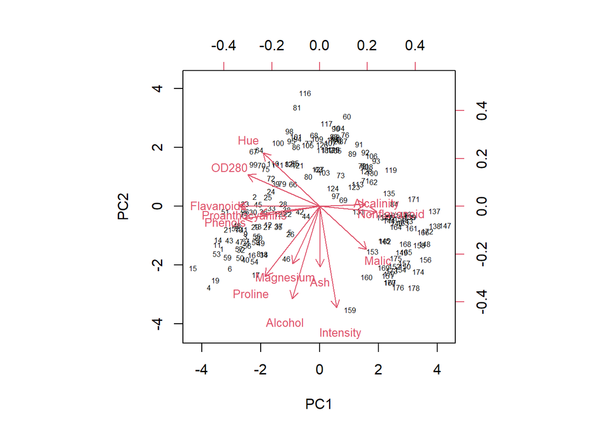

```r
biplot(pca, scale = 0, cex = c(0.5, 0.8))
```

**Relationship Between Variables:** Variables with arrows pointing in similar directions are *positively correlated*. An example of this is the group of arrows corresponding with the variables **flavanoids**, **phenols**, and **proanthocyanins**.

Variables with arrows pointing in opposite directions are *negatively correlated*. An example of this is the variable **hue** and the variable **malic**, who have arrows pointing in opposite directions.

The longer the arrows are for variables, the more heavily weighted they are in the principal components. This means that a variable like **intensity** is more heavily weighted than a variable like **ash**.

**Variance Explained by Principal Components:** The first principal component (PC1) corresponds with the highest portion of variance explained, and that lies along the x-axis. This means that variables that lie among the x-axis like **flavanoids**, **phenols**, **proanthocyanins**, **alcalinity**, and **nonflavanoid** weigh most heavily for the first principal component.

The second principal component (PC2) represents the second highest portion of variance explained, less than what is explained by PC1. It lies along the y-axis. This means that variables that lie among the y-axis like **intensity**, **ash**, and **alcohol** weigh most heavily for the second principal component. However, these variables explain less total variance than the variables used in the first principal component.

**Observed Clustering Patterns:** Clusters of observations indicate that they are similar, and may belong to the same group. On this biplot, we can observe distinct groups on the left, top, and right of the plot.

# Exercise 14

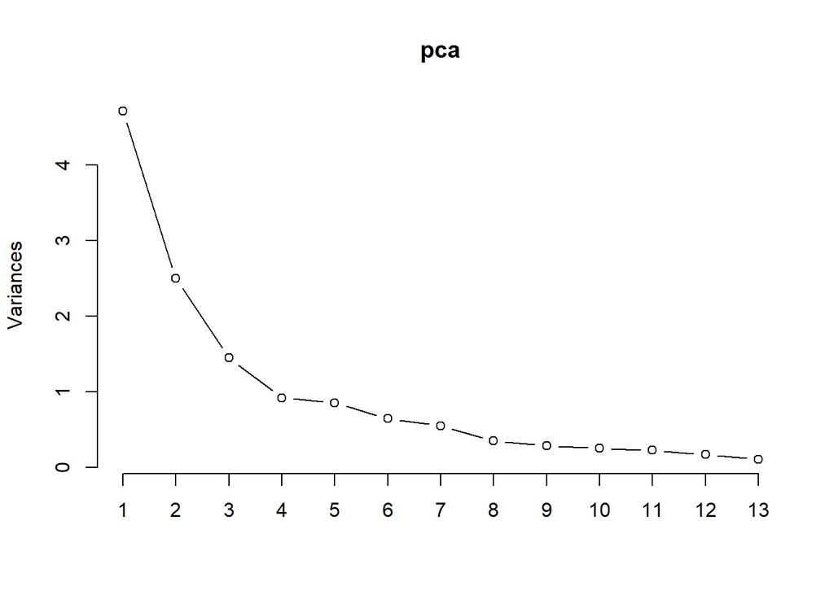

```r
plot(pca, type="lines", npcs = 13)
```

```r
#It is not entirely clear what "How much variance do this principal components retrain from the original data set" means.
```

The scree plot appears to suggest that we keep either 3 or 4 principal components, it isn’t entirely clear. That is where the elbow point where the scree plot levels off is. Looking back to the output in Exercise 12, 3 principal components explain 66.53% of the variance in the data set, while 4 principal components explain 73.6% of the variance in the data set.

# Exercise 15

Looking at the output of Exercise 12, we should retain 3 principal components according to the Kaiser criterion. While the Kaiser criterion keeps principal components with eigenvalues greater than 1, we can still use the eigenvalue^2 (Standard Deviation) since anything greater than one squared is greater than one, and anything less than one squared is less than one.

# Exercise 16

```r
library(MASS)
pca_scores <- pca$x
selectedpca <- pca_scores[, 1:5]
lda_data <- data.frame(selectedpca, Class = dataW$Class)

ldaModel <- lda(Class ~ ., data = lda_data)
predLDA <- predict(ldaModel)
factoredLDA <- as.factor(predLDA$class)
factoredClass <- as.factor(dataW$Class)
CMLDA <- confusionMatrix(factoredClass, factoredLDA)
accLDA <- CMLDA$overall['Accuracy']
MCRLDA <- 1 - as.numeric(accLDA)
MCRLDA
```

```
[1] 0.02247191
```